# A3

Suraj Chandrasekhar

May 6, 2018

# National Level

The factor I am looking into in the BRFSS survey is looking at the smoking tendencies. I have taken several factors while looking at smoking tendencies in the United States for people over the age of 18. Since there is not around 250 million respondents to the surveys, but rather around 486,303 respondents, we are looking at the sample weights of each respondent to give an estimation on the general trends in the U.S. The smoking factors that were asked in the survey include, have you smoked more than 100 cigarettes in your entire life, How often do you smoke cigarettes, have you quit smoking for the past 12 months, do you use non-smoking tobacco, and your position on e-cigarettes. The first aspect I looked into was seeing the level at which people smoke in the U.S. on a national scale level. To get a better understanding of the general populations, I took a sum of the survey weights, as these weights are representative of getting the total population, and the survey demonstrates the most of the population does not smoke cigarettes, while if you do smoke, you are most likely to smoke everyday than on-and-off, showing the addictiveness of this drug.

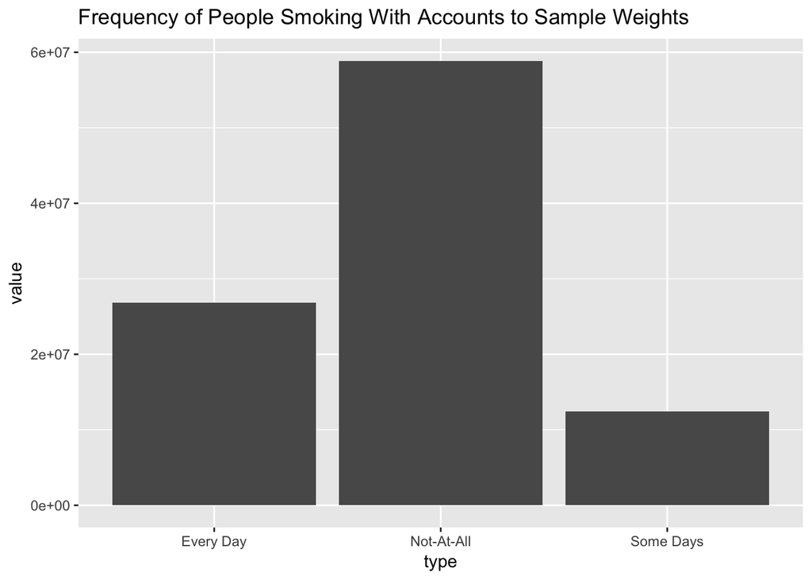

The part of the data I want to look at is looking at how smoking tendencies lead to people using alternatives to cigarettes. The two major alternatives to smoking cigarettes is smokeless tobacco and e-cigarettes. Smokeless tobacco, the most common type is chewing tobacco, has the same chemical formula as cigarettes, but its not smoked. Looking at the graph belows, it seems like people who smoke everyday or do not smoke are both unlikely to use smokeless tobacco, while people who occasionally smoke are also unlikely to use smokeless tobacco, but are more likely to occassionally use it than the others. This makes a little sense since tobacco/nicotine is an addictive drug, so people that occassionally smoke cigarettes are still dependent on tobacco, so they find other alternatives to smoking as well, such as “dipping”, or taking smokeless tobacco.

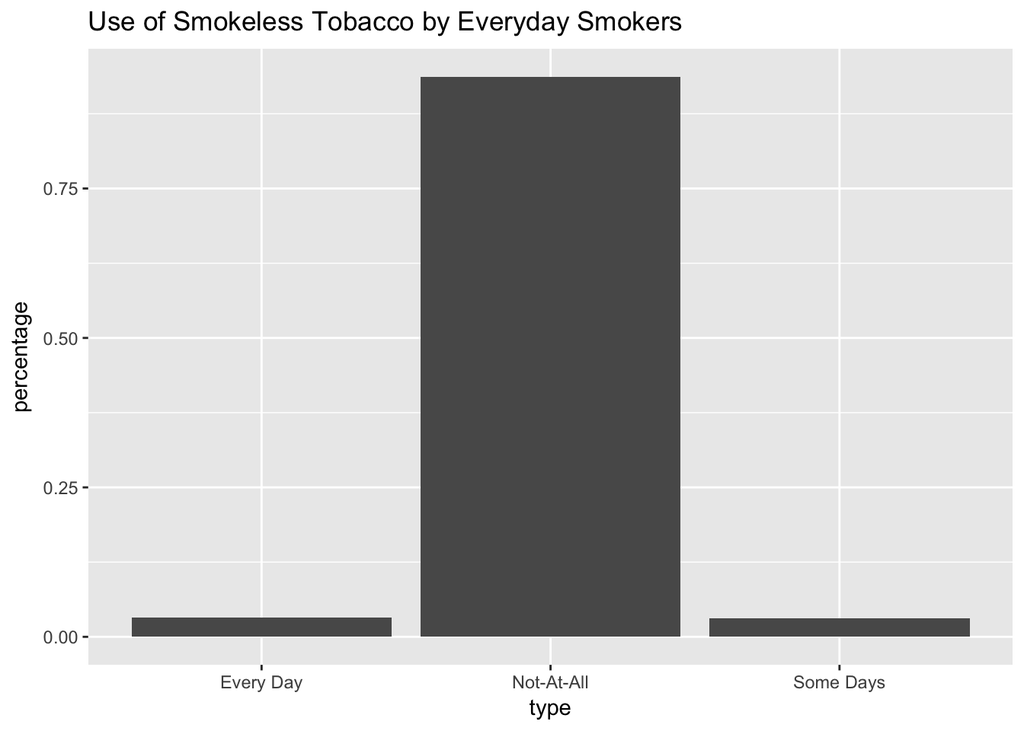

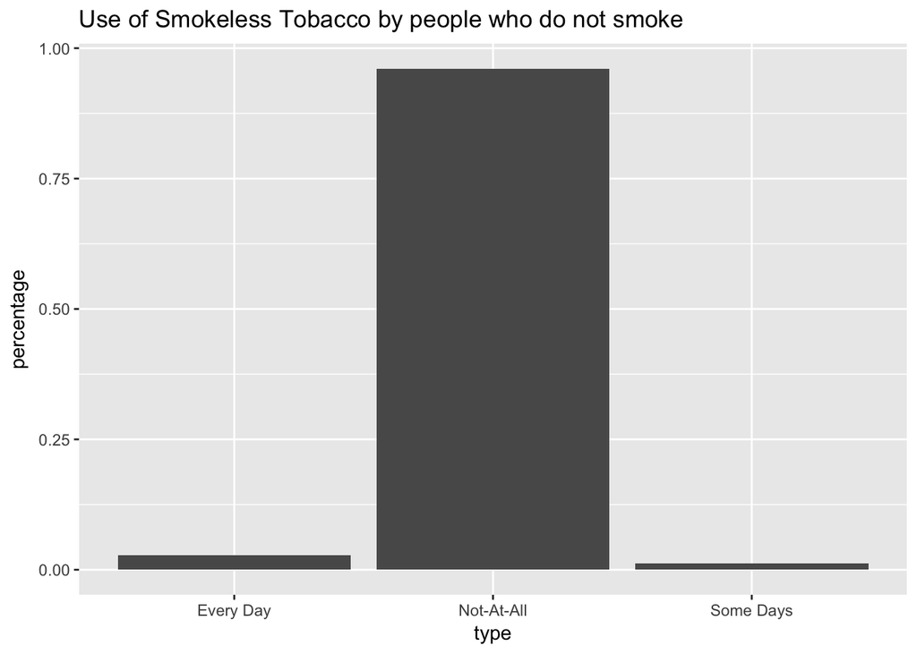

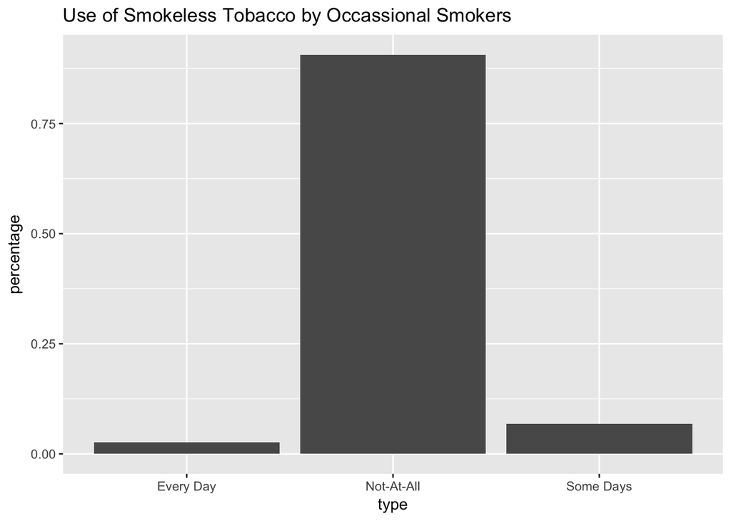

Another alternative to smoking cigarettes is smoking e-cigarettes, or vaping. E-cigarettes is smoking a nicotine based vapor and simulates the feeling of smoking tobacco cigarettes, but has shown to have less long term effects than normal cigarettes. The graphs below shown that people who have smoked cigarettes have also tried out e-cigarettes, which makes sense as they are maybe looking for alternatives to ease their way into quitting, while people who have never smoked a cigarette are likely to have never tried e-Cigarettes either. This maybe that they feel that they are not interested in the idea of smoking or because they might feel that smoking e-Cigarettes will likely lead them to try regular cigarettes.

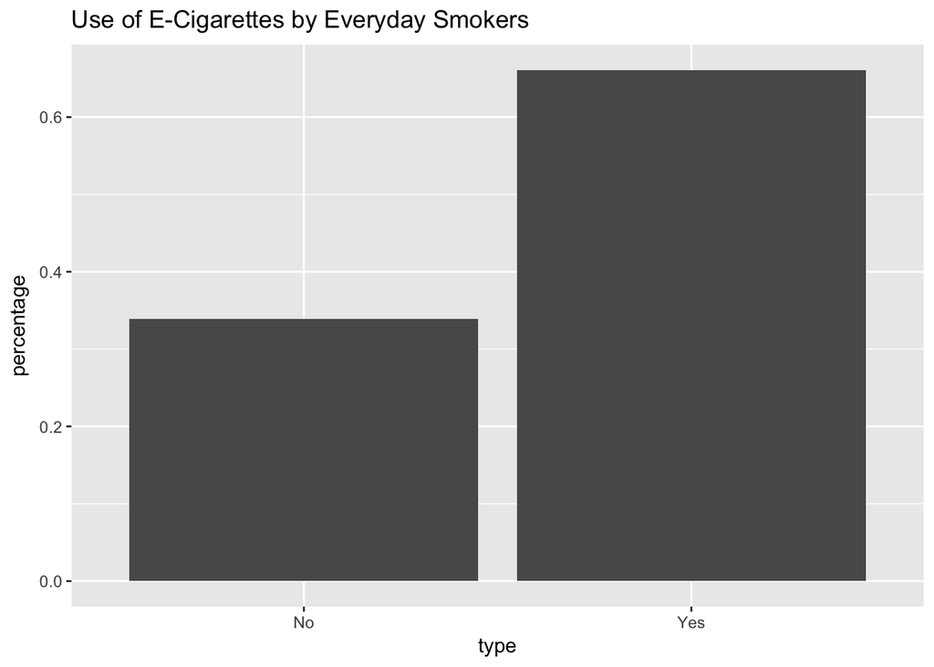

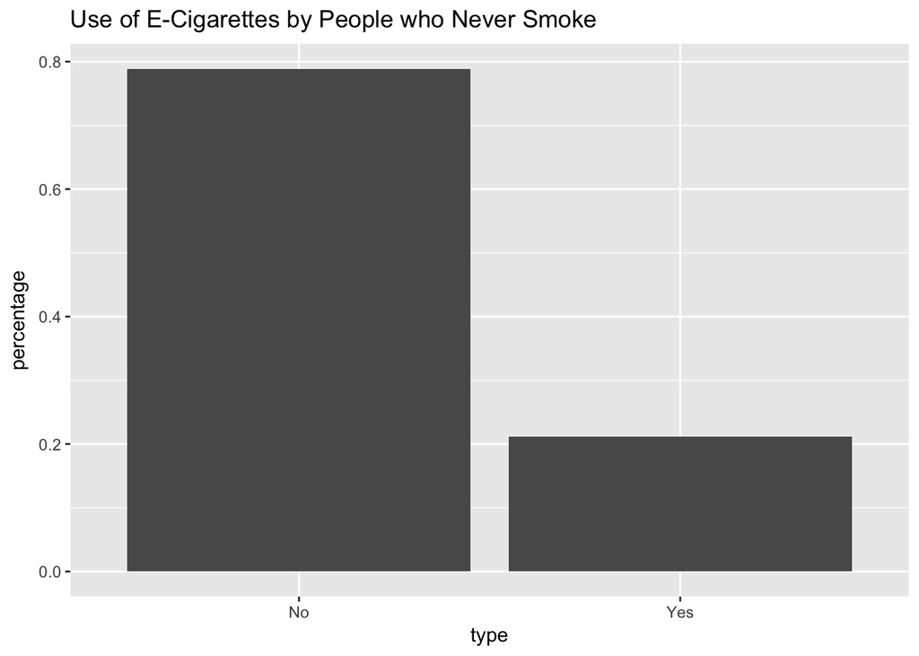

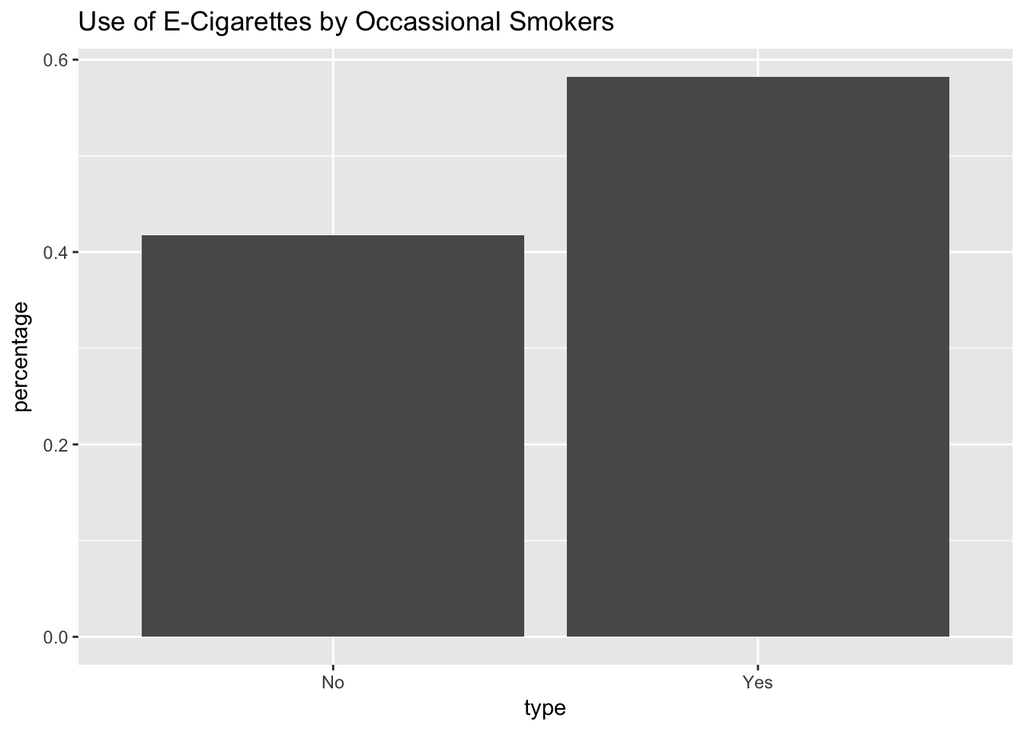